MHBs in normal tissues

mHaps

# The DNA methylation haplotype map of normal tissues

## Abstract

DNA methylation plays an important role in regulating gene expression by controlling the accessibility of the DNA to the transcription machinery. Previous identification of DNA methylation-associated regulatory elements was mainly focused on mean methylation, resulting in the discovery of unmethylated regions (UMRs) and low-methylation regions (LMRs) that are enriched in promoters and enhancers, respectively. However, whole genome bisulfite sequencing (WGBS) enables the characterization of DNA methylation haplotypes (mHaps) that define the CpGs on the same read fragment from a single chromosome. It has been established that adjacent CpGs on the same fragment can be co-methylated, creating methylation haplotype blocks (MHBs). In this study, we utilized manually curated WGBS datasets to identify MHBs in human preimplantation embryos and 17 representative normal tissues. Our integrative analysis demonstrated that MHBs are enriched with open chromatin regions and tissue-specific histone marks and enhancers, including super-enhancers. Moreover, MHBs tend to be situated near tissue-specific genes and are associated with differential gene expression independent of mean methylation. Finally, we found evidence that DNMT3B maintains MHBs in mouse ES cells. In conclusion, MHBs represent a novel type of DNA methylation-associated regulatory elements that are characterized by DNA methylation patterns rather than mean methylation.

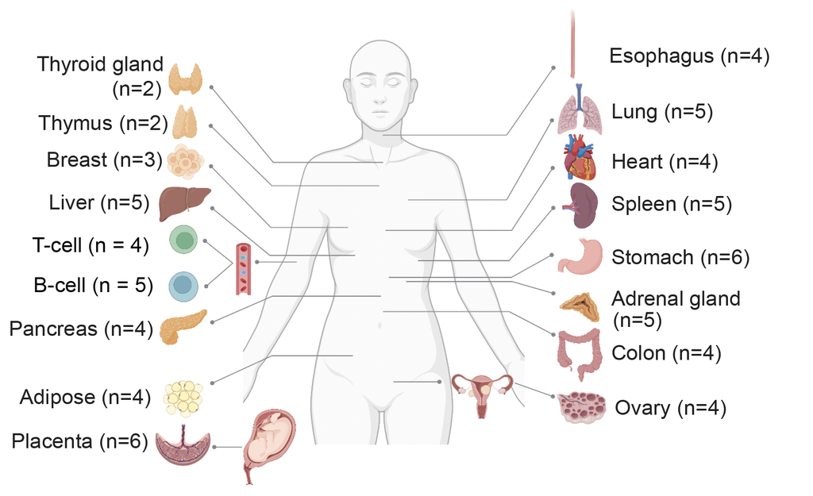

Shanghai Institute of Biochemistry and Cell Biology, Center for Excellence in Molecular Cell Science, CAS